# Kaggle - Don’t Overfit 2

2019-04-16

```r
library(tidyverse)
library(caret)
library(broom)
```

Load and inspect data

```r
df_train <- read_csv("train.csv")
str(df_train)
sum(is.na(df_train))
df_train_cov <- df_train %>% select(-id, -target)
```

Data preprocessing

```r
nearZeroVar(df_train_cov, saveMetrics = T)
```

```
    freqRatio percentUnique zeroVar   nzv
0         1.0          96.8   FALSE FALSE
1         1.0          97.2   FALSE FALSE
2         1.5          95.2   FALSE FALSE
3         1.0          98.0   FALSE FALSE
4         1.0          97.2   FALSE FALSE
5         1.0          97.6   FALSE FALSE
6         1.0          96.8   FALSE FALSE
7         1.0          97.6   FALSE FALSE
8         1.0          95.6   FALSE FALSE
9         1.0          97.2   FALSE FALSE
10        1.0          94.8   FALSE FALSE
11        1.0          96.0   FALSE FALSE
12        1.0          98.0   FALSE FALSE
13        1.5          97.2   FALSE FALSE
```

[output cut: 286 more lines]

```r
findCorrelation(cor(df_train_cov), cutoff = 0.5)
```

```
numeric(0)
```

```r
lin_combos <- findLinearCombos(as.matrix(df_train_cov))
lin_combos$remove
```

```
 [1] 251 252 253 254 255 256 257 258 259 260 261 262 263 264 265 266 267 268 269 270 271 272 273 274 275 276 277 278 279 280 281 282
[33] 283 284 285 286 287 288 289 290 291 292 293 294 295 296 297 298 299 300
```

```r
sum(is.na(df_train_cov))
```

```
[1] 0
```

```r
pre_proc <- preProcess(df_train_cov, method = c("center", "scale", "pca"))
df_train_cov2 <- predict(pre_proc, df_train_cov)
```

No problems with zero- and near zero- variance. No autocorrelation. Features 251-300 are linear combinations No missing values. Center, scale, reduce to principal components

Train model using eXtreme Gradient Boosting - DART (Dropouts meet Multiple Additive Regression Trees) Use bootstrapping due to small sample size

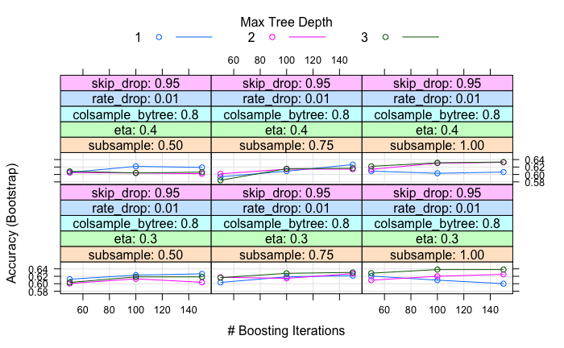

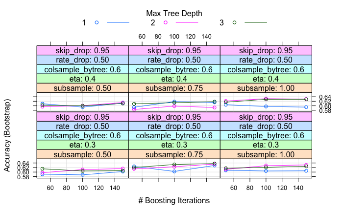

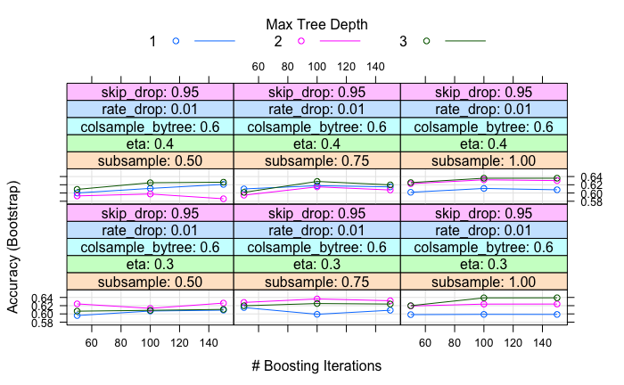

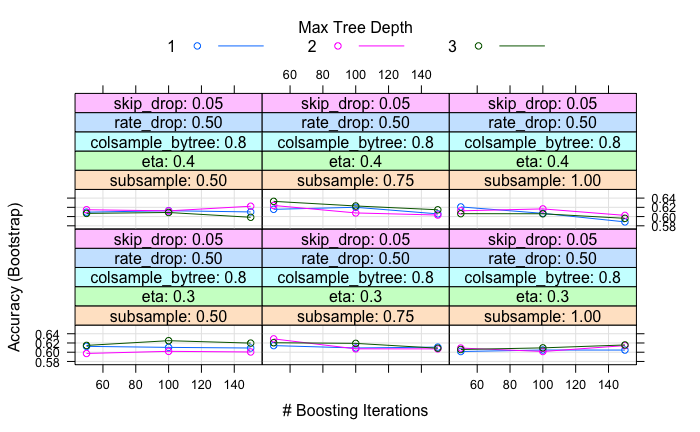

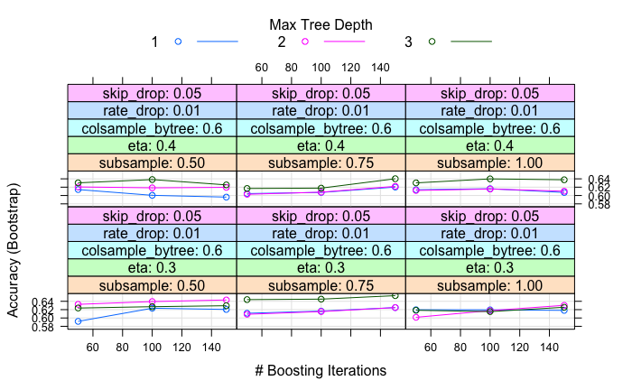

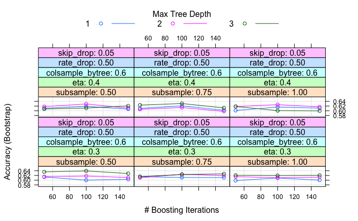

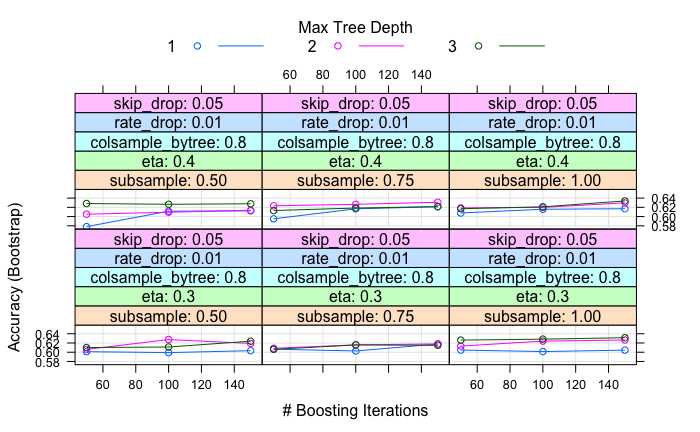

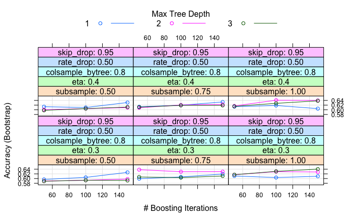

The final values used for the model were nrounds = 150, max_depth = 3, eta = 0.3, gamma = 0, subsample = 0.75, colsample_bytree = 0.6, rate_drop = 0.01, skip_drop = 0.05 and min_child_weight = 1.

Fit model using these more conservative parameters

```r
xgbfit2
```

```
eXtreme Gradient Boosting

250 samples
166 predictors
  2 classes: '0', '1'

No pre-processing
Resampling: Bootstrapped (10 reps)
Summary of sample sizes: 250, 250, 250, 250, 250, 250, ...
Resampling results across tuning parameters:

  min_child_weight  subsample  colsample_bytree  gamma  nrounds  Accuracy   Kappa
   1                0.50       0.3333333          1      50      0.6547910  0.07641492
   1                0.50       0.3333333          1     100      0.6510168  0.08938197
   1                0.50       0.3333333          1     150      0.6479489  0.09827985
```

[output cut: 115 more lines]

The final values used for the model were nrounds = 150, max_depth = 1, eta = 0.05, gamma = 1, subsample = 0.5, colsample_bytree = 0.6666667, rate_drop = 0.01, skip_drop = 0.05 and min_child_weight = 10.

Prepare test data

```r
df_test <- read_csv("test.csv")
df_test <- read_csv("test.csv")
df_test2 <- select(df_test, -id)
df_test2 <- predict(pre_proc, df_test2)
```

Fit model to test data

```r
predicted <- predict(xgbfit, df_test2)
```

```
Error in predict(xgbfit, df_test2) : object 'xgbfit' not found
```

Save as CSV

```r
write_csv(data.frame(df_test$id, predicted1), "predicted1.csv")
```

```
Unknown or uninitialised column: 'id'.Error in is.data.frame(x) :
  arguments imply differing number of rows: 0, 19750
```

Let’s try logistic regression with lasso regularization

```r
df_train_cov3 <- predict(pre_proc, df_train_cov)
```

```
Error in predict(pre_proc, df_train_cov) : object 'pre_proc' not found
```

Find the best lambda using CV

```r
cv_lasso$lambda.1se
```

```
[1] 0.0560541
```

Using lambda.lse will be more conservative than using lambda.min

```r
summary(mod_lasso)
```

```
           Length Class     Mode
a0           100  -none-    numeric
beta       30000  dgCMatrix S4
df           100  -none-    numeric
dim            2  -none-    numeric
lambda       100  -none-    numeric
dev.ratio    100  -none-    numeric
nulldev        1  -none-    numeric
npasses        1  -none-    numeric
jerr           1  -none-    numeric
offset         1  -none-    logical
classnames     2  -none-    character
call           5  -none-    call
nobs           1  -none-    numeric
```

Prepare test data

```r
df_test <- read_csv("test.csv")
df_test3 <- select(df_test, -id)
df_test3 <- predict(pre_proc2, df_test3)
```

Make predicitons on test data

```r
write_csv(data.frame(id = df_test$id, target = vector(predicted3)), "predicted3.csv")
```

```
Error in is.data.frame(x) : invalid 'mode' argument
```

Let’s try using elastic net - blending of ridge and lasso regularization

```r
df_train4 <- df_train %>%
  select(target) %>%
  mutate(target = as.factor(target)) %>%
  bind_cols(df_train_cov3)
set.seed(1234)
fit_control <- trainControl(method = "cv",
                            number = 10)
glmgrid <- expand.grid(alpha = seq(0, 1, by = .1),
                       lambda = seq(0, .1, by = .01)
                       )
glm_fit <- train(target ~ .,
                 data = df_train4,
                 method = "glmnet",
                 trControl = fit_control,
                 tuneGrid = glmgrid)
```

```r
glm_fit
```

```
glmnet

250 samples
300 predictors
  2 classes: '0', '1'

No pre-processing
Resampling: Cross-Validated (10 fold)
Summary of sample sizes: 225, 225, 225, 225, 225, 225, ...
Resampling results across tuning parameters:

  alpha  lambda  Accuracy  Kappa
  0.0    0.00    0.652     0.04137931
  0.0    0.01    0.652     0.04137931
  0.0    0.02    0.652     0.04137931
  0.0    0.03    0.652     0.04137931
  0.0    0.04    0.652     0.04137931
  0.0    0.05    0.652     0.04137931
  0.0    0.06    0.652     0.04137931
  0.0    0.07    0.652     0.04137931
  0.0    0.08    0.652     0.04137931
  0.0    0.09    0.652     0.04137931
  0.0    0.10    0.652     0.04137931
  0.1    0.00    0.716     0.36041938
  0.1    0.01    0.716     0.36041938
  0.1    0.02    0.716     0.36041938
  0.1    0.03    0.724     0.37468682
  0.1    0.04    0.732     0.39005048
  0.1    0.05    0.732     0.38765840
  0.1    0.06    0.728     0.37746415
  0.1    0.07    0.728     0.37334529
  0.1    0.08    0.728     0.37109957
  0.1    0.09    0.728     0.36662289
  0.1    0.10    0.732     0.37101379
  0.2    0.00    0.724     0.39219112
  0.2    0.01    0.724     0.38952993
  0.2    0.02    0.732     0.40272483
  0.2    0.03    0.736     0.40319447
  0.2    0.04    0.736     0.40128887
  0.2    0.05    0.744     0.42121724
```

[output cut: 81 more lines]

```
  0.9    0.10    0.680     0.16160262
  1.0    0.00    0.716     0.37710487
  1.0    0.01    0.732     0.40448297
  1.0    0.02    0.732     0.40380763
  1.0    0.03    0.740     0.41570718
  1.0    0.04    0.740     0.38138988
  1.0    0.05    0.740     0.37381705
  1.0    0.06    0.704     0.26861173
  1.0    0.07    0.700     0.24241279
  1.0    0.08    0.692     0.20996753
  1.0    0.09    0.676     0.15411887
  1.0    0.10    0.656     0.08381283

Accuracy was used to select the optimal model using the largest value.
The final values used for the model were alpha = 0.2 and lambda = 0.08.
```

Best model uses alpha = 0.2 and lambda = 0.08 for a CV accuracy of .75

```r
predicted4 <- predict(flm_fit, df_test3)
```

```
Error in predict(flm_fit, df_test3) : object 'flm_fit' not found
```